# Project: Movie database Data Analysis

- Introduction
- Data Wrangling
- Exploratory Data Analysis
- Conclusions

I analyze the movie database and answering the questions,

- which genres are most popular from year to year?
- what kinds of properties are associated with movies that have high revenues?
- Which movie is the most popular through years?
- etc

I used numpy, pandas to investigate and plot to show in the end. I did data wrangling, such as identify null, duplicate investigation. The summary statistics and plots in the end of the notes

## Introduction

This data set contains information about 10,000 movies collected from The Movie Database (TMDb), including user ratings and revenue.

Questions:

- Which genres are most popular from year to year?
- What kinds of properties are associated with movies that have high revenues?

```python
import pandas as pd
import numpy as np
import matplotlib.pyplot as plt
import seaborn as sns
%matplotlib inline
```

## Data Wrangling

### General Properties

```python
df = pd.read_csv('tmdb-movies.csv')
df.head()
```

|  | id | imdb_id | popularity | budget | revenue | original_title | cast | homepage | director | tagline | ... | overview | runtime | genres | production_companies | release_date | vote_count | vote_average | release_year | budget_adj | revenue_adj |
| --- | --- | --- | --- | --- | --- | --- | --- | --- | --- | --- | --- | --- | --- | --- | --- | --- | --- | --- | --- | --- | --- |
| 0 | 135397 | tt0369610 | 32.985763 | 150000000 | 1513528810 | Jurassic World | Chris Pratt\|Bryce Dallas Howard\|Irrfan Khan\|Vi... | http://www.jurassicworld.com/ | Colin Trevorrow | The park is open. | ... | Twenty-two years after the events of Jurassic ... | 124 | Action\|Adventure\|Science Fiction\|Thriller | Universal Studios\|Amblin Entertainment\|Legenda... | 6/9/15 | 5562 | 6.5 | 2015 | 1.379999e+08 | 1.392446e+09 |
| 1 | 76341 | tt1392190 | 28.419936 | 150000000 | 378436354 | Mad Max: Fury Road | Tom Hardy\|Charlize Theron\|Hugh Keays-Byrne\|Nic... | http://www.madmaxmovie.com/ | George Miller | What a Lovely Day. | ... | An apocalyptic story set in the furthest reach... | 120 | Action\|Adventure\|Science Fiction\|Thriller | Village Roadshow Pictures\|Kennedy Miller Produ... | 5/13/15 | 6185 | 7.1 | 2015 | 1.379999e+08 | 3.481613e+08 |
| 2 | 262500 | tt2908446 | 13.112507 | 110000000 | 295238201 | Insurgent | Shailene Woodley\|Theo James\|Kate Winslet\|Ansel... | http://www.thedivergentseries.movie/#insurgent | Robert Schwentke | One Choice Can Destroy You | ... | Beatrice Prior must confront her inner demons ... | 119 | Adventure\|Science Fiction\|Thriller | Summit Entertainment\|Mandeville Films\|Red Wago... | 3/18/15 | 2480 | 6.3 | 2015 | 1.012000e+08 | 2.716190e+08 |
| 3 | 140607 | tt2488496 | 11.173104 | 200000000 | 2068178225 | Star Wars: The Force Awakens | Harrison Ford\|Mark Hamill\|Carrie Fisher\|Adam D... | http://www.starwars.com/films/star-wars-episod... | J.J. Abrams | Every generation has a story. | ... | Thirty years after defeating the Galactic Empi... | 136 | Action\|Adventure\|Science Fiction\|Fantasy | Lucasfilm\|Truenorth Productions\|Bad Robot | 12/15/15 | 5292 | 7.5 | 2015 | 1.839999e+08 | 1.902723e+09 |
| 4 | 168259 | tt2820852 | 9.335014 | 190000000 | 1506249360 | Furious 7 | Vin Diesel\|Paul Walker\|Jason Statham\|Michelle ... | http://www.furious7.com/ | James Wan | Vengeance Hits Home | ... | Deckard Shaw seeks revenge against Dominic Tor... | 137 | Action\|Crime\|Thriller | Universal Pictures\|Original Film\|Media Rights ... | 4/1/15 | 2947 | 7.3 | 2015 | 1.747999e+08 | 1.385749e+09 |

5 rows × 21 columns

- The shape of the data is (10866, 21) and the data has big range, need scaling in the future

```python
df.info()
```

```
<class 'pandas.core.frame.DataFrame'>
RangeIndex: 10866 entries, 0 to 10865
Data columns (total 21 columns):
 #   Column                Non-Null Count  Dtype
---  ------                --------------  -----
 0   id                    10866 non-null  int64
 1   imdb_id               10856 non-null  object
 2   popularity            10866 non-null  float64
 3   budget                10866 non-null  int64
 4   revenue               10866 non-null  int64
 5   original_title        10866 non-null  object
 6   cast                  10790 non-null  object
 7   homepage              2936 non-null   object
 8   director              10822 non-null  object
 9   tagline               8042 non-null   object
 10  keywords              9373 non-null   object
 11  overview              10862 non-null  object
 12  runtime               10866 non-null  int64
 13  genres                10843 non-null  object
 14  production_companies  9836 non-null   object
 15  release_date          10866 non-null  object
 16  vote_count            10866 non-null  int64
 17  vote_average          10866 non-null  float64
 18  release_year          10866 non-null  int64
 19  budget_adj            10866 non-null  float64
 20  revenue_adj           10866 non-null  float64
dtypes: float64(4), int64(6), object(11)
memory usage: 1.7+ MB
```

```python
df.describe()
```

|  | id | popularity | budget | revenue | runtime | vote_count | vote_average | release_year | budget_adj | revenue_adj |
| --- | --- | --- | --- | --- | --- | --- | --- | --- | --- | --- |
| count | 10866.000000 | 10866.000000 | 1.086600e+04 | 1.086600e+04 | 10866.000000 | 10866.000000 | 10866.000000 | 10866.000000 | 1.086600e+04 | 1.086600e+04 |
| mean | 66064.177434 | 0.646441 | 1.462570e+07 | 3.982332e+07 | 102.070863 | 217.389748 | 5.974922 | 2001.322658 | 1.755104e+07 | 5.136436e+07 |
| std | 92130.136561 | 1.000185 | 3.091321e+07 | 1.170035e+08 | 31.381405 | 575.619058 | 0.935142 | 12.812941 | 3.430616e+07 | 1.446325e+08 |
| min | 5.000000 | 0.000065 | 0.000000e+00 | 0.000000e+00 | 0.000000 | 10.000000 | 1.500000 | 1960.000000 | 0.000000e+00 | 0.000000e+00 |
| 25% | 10596.250000 | 0.207583 | 0.000000e+00 | 0.000000e+00 | 90.000000 | 17.000000 | 5.400000 | 1995.000000 | 0.000000e+00 | 0.000000e+00 |
| 50% | 20669.000000 | 0.383856 | 0.000000e+00 | 0.000000e+00 | 99.000000 | 38.000000 | 6.000000 | 2006.000000 | 0.000000e+00 | 0.000000e+00 |
| 75% | 75610.000000 | 0.713817 | 1.500000e+07 | 2.400000e+07 | 111.000000 | 145.750000 | 6.600000 | 2011.000000 | 2.085325e+07 | 3.369710e+07 |
| max | 417859.000000 | 32.985763 | 4.250000e+08 | 2.781506e+09 | 900.000000 | 9767.000000 | 9.200000 | 2015.000000 | 4.250000e+08 | 2.827124e+09 |

- popularity, run time, seem have an outlier to influence the data, might need to check it later. check any null value for datasets
- Also need to check out the null value for further exploring

```python
df[df['cast'].isnull()].head()
```

|  | id | imdb_id | popularity | budget | revenue | original_title | cast | homepage | director | tagline | ... | overview | runtime | genres | production_companies | release_date | vote_count | vote_average | release_year | budget_adj | revenue_adj |
| --- | --- | --- | --- | --- | --- | --- | --- | --- | --- | --- | --- | --- | --- | --- | --- | --- | --- | --- | --- | --- | --- |
| 371 | 345637 | tt4661600 | 0.422901 | 0 | 0 | Sanjay's Super Team | NaN | NaN | Sanjay Patel | NaN | ... | Sanjay's Super Team follows the daydream of a ... | 7 | Animation | Pixar Animation Studios | 11/25/15 | 47 | 6.9 | 2015 | 0.0 | 0.0 |
| 441 | 355020 | tt4908644 | 0.220751 | 0 | 0 | Winter on Fire: Ukraine's Fight for Freedom | NaN | http://www.netflix.com/title/80031666 | Evgeny Afineevsky | The Next Generation Of Revolution | ... | A documentary on the unrest in Ukraine during ... | 98 | Documentary | Passion Pictures\|Campbell Grobman Films\|Afinee... | 10/9/15 | 37 | 8.2 | 2015 | 0.0 | 0.0 |
| 465 | 321109 | tt4393514 | 0.201696 | 0 | 0 | Bitter Lake | NaN | NaN | Adam Curtis | NaN | ... | An experimental documentary that explores Saud... | 135 | Documentary | BBC | 1/24/15 | 19 | 7.8 | 2015 | 0.0 | 0.0 |
| 536 | 333350 | tt3762974 | 0.122543 | 0 | 0 | A Faster Horse | NaN | NaN | David Gelb | NaN | ... | David Gelb (Jiro Dreams of Sushi) tackles anot... | 90 | Documentary | NaN | 10/8/15 | 12 | 8.0 | 2015 | 0.0 | 0.0 |
| 538 | 224972 | tt3983674 | 0.114264 | 0 | 0 | The Mask You Live In | NaN | http://themaskyoulivein.org | Jennifer Siebel Newsom | Is american masculinity harming our boys, men ... | ... | Compared to girls, research shows that boys in... | 88 | Documentary | NaN | 1/1/15 | 11 | 8.9 | 2015 | 0.0 | 0.0 |

5 rows × 21 columns

- Check the duplicated value and drop it since not really influence the whole analyzing

```python
df[df.duplicated()]
```

|  | id | imdb_id | popularity | budget | revenue | original_title | cast | homepage | director | tagline | ... | overview | runtime | genres | production_companies | release_date | vote_count | vote_average | release_year | budget_adj | revenue_adj |
| --- | --- | --- | --- | --- | --- | --- | --- | --- | --- | --- | --- | --- | --- | --- | --- | --- | --- | --- | --- | --- | --- |
| 2090 | 42194 | tt0411951 | 0.59643 | 30000000 | 967000 | TEKKEN | Jon Foo\|Kelly Overton\|Cary-Hiroyuki Tagawa\|Ian... | NaN | Dwight H. Little | Survival is no game | ... | In the year of 2039, after World Wars destroy ... | 92 | Crime\|Drama\|Action\|Thriller\|Science Fiction | Namco\|Light Song Films | 3/20/10 | 110 | 5.0 | 2010 | 30000000.0 | 967000.0 |

1 rows × 21 columns

```python
df.drop_duplicates(inplace=True)
```

- Check the the distributions of all attributes to get big picture of all the data

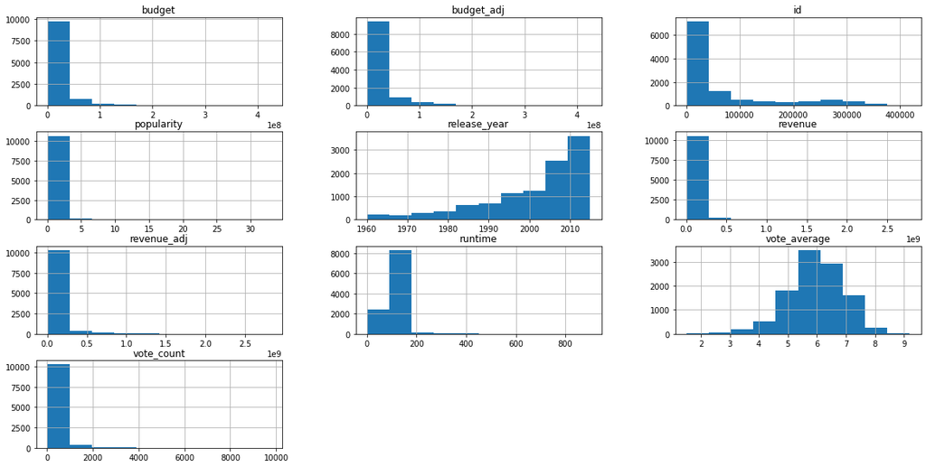

```python
df.hist(figsize=(20,10));
```

- left skewed happened in relase_year and the datasets have big range in gneral
- Do not need id, title name and some others info for further analyzing

```python
df.drop(['id','imdb_id','original_title','production_companies','tagline','overview','homepage','keywords','cast','director'],axis=1,inplace=True)
```

```python
df.head()
```

|  | popularity | budget | revenue | runtime | genres | release_date | vote_count | vote_average | release_year | budget_adj | revenue_adj |
| --- | --- | --- | --- | --- | --- | --- | --- | --- | --- | --- | --- |
| 0 | 32.985763 | 150000000 | 1513528810 | 124 | Action\|Adventure\|Science Fiction\|Thriller | 6/9/15 | 5562 | 6.5 | 2015 | 1.379999e+08 | 1.392446e+09 |
| 1 | 28.419936 | 150000000 | 378436354 | 120 | Action\|Adventure\|Science Fiction\|Thriller | 5/13/15 | 6185 | 7.1 | 2015 | 1.379999e+08 | 3.481613e+08 |
| 2 | 13.112507 | 110000000 | 295238201 | 119 | Adventure\|Science Fiction\|Thriller | 3/18/15 | 2480 | 6.3 | 2015 | 1.012000e+08 | 2.716190e+08 |
| 3 | 11.173104 | 200000000 | 2068178225 | 136 | Action\|Adventure\|Science Fiction\|Fantasy | 12/15/15 | 5292 | 7.5 | 2015 | 1.839999e+08 | 1.902723e+09 |
| 4 | 9.335014 | 190000000 | 1506249360 | 137 | Action\|Crime\|Thriller | 4/1/15 | 2947 | 7.3 | 2015 | 1.747999e+08 | 1.385749e+09 |

```python
df.info()
```

```
<class 'pandas.core.frame.DataFrame'>
Int64Index: 10865 entries, 0 to 10865
Data columns (total 11 columns):
 #   Column        Non-Null Count  Dtype
---  ------        --------------  -----
 0   popularity    10865 non-null  float64
 1   budget        10865 non-null  int64
 2   revenue       10865 non-null  int64
 3   runtime       10865 non-null  int64
 4   genres        10842 non-null  object
 5   release_date  10865 non-null  object
 6   vote_count    10865 non-null  int64
 7   vote_average  10865 non-null  float64
 8   release_year  10865 non-null  int64
 9   budget_adj    10865 non-null  float64
 10  revenue_adj   10865 non-null  float64
dtypes: float64(4), int64(5), object(2)
memory usage: 1018.6+ KB
```

- 'genres' need to be seperated from '|'
- Drop the null data

```python
df.dropna(inplace=True)
```

```python
df[df['genres'].str.contains('|')].head()
```

|  | popularity | budget | revenue | runtime | genres | release_date | vote_count | vote_average | release_year | budget_adj | revenue_adj |
| --- | --- | --- | --- | --- | --- | --- | --- | --- | --- | --- | --- |
| 0 | 32.985763 | 150000000 | 1513528810 | 124 | Action\|Adventure\|Science Fiction\|Thriller | 6/9/15 | 5562 | 6.5 | 2015 | 1.379999e+08 | 1.392446e+09 |
| 1 | 28.419936 | 150000000 | 378436354 | 120 | Action\|Adventure\|Science Fiction\|Thriller | 5/13/15 | 6185 | 7.1 | 2015 | 1.379999e+08 | 3.481613e+08 |
| 2 | 13.112507 | 110000000 | 295238201 | 119 | Adventure\|Science Fiction\|Thriller | 3/18/15 | 2480 | 6.3 | 2015 | 1.012000e+08 | 2.716190e+08 |
| 3 | 11.173104 | 200000000 | 2068178225 | 136 | Action\|Adventure\|Science Fiction\|Fantasy | 12/15/15 | 5292 | 7.5 | 2015 | 1.839999e+08 | 1.902723e+09 |
| 4 | 9.335014 | 190000000 | 1506249360 | 137 | Action\|Crime\|Thriller | 4/1/15 | 2947 | 7.3 | 2015 | 1.747999e+08 | 1.385749e+09 |

```python
df1 = df[0:0]
# type(df)
df2 = df1.copy()

for i in df.index:
    array = df['genres'][i].split('|')
    for genre in array:
        dftemp = df[i:i+1].copy()
        dftemp['genres'] = genre
        df2 = df2.append(dftemp, ignore_index=True)
```

```python
df2
```

|  | popularity | budget | revenue | runtime | genres | release_date | vote_count | vote_average | release_year | budget_adj | revenue_adj |
| --- | --- | --- | --- | --- | --- | --- | --- | --- | --- | --- | --- |
| 0 | 32.985763 | 150000000 | 1513528810 | 124 | Action | 6/9/15 | 5562 | 6.5 | 2015 | 1.379999e+08 | 1.392446e+09 |
| 1 | 32.985763 | 150000000 | 1513528810 | 124 | Adventure | 6/9/15 | 5562 | 6.5 | 2015 | 1.379999e+08 | 1.392446e+09 |
| 2 | 32.985763 | 150000000 | 1513528810 | 124 | Science Fiction | 6/9/15 | 5562 | 6.5 | 2015 | 1.379999e+08 | 1.392446e+09 |
| 3 | 32.985763 | 150000000 | 1513528810 | 124 | Thriller | 6/9/15 | 5562 | 6.5 | 2015 | 1.379999e+08 | 1.392446e+09 |
| 4 | 28.419936 | 150000000 | 378436354 | 120 | Action | 5/13/15 | 6185 | 7.1 | 2015 | 1.379999e+08 | 3.481613e+08 |
| ... | ... | ... | ... | ... | ... | ... | ... | ... | ... | ... | ... |
| 26887 | 0.065543 | 0 | 0 | 176 | Western | 12/21/66 | 20 | 5.7 | 1966 | 0.000000e+00 | 0.000000e+00 |
| 26888 | 0.065141 | 0 | 0 | 94 | Family | 1/1/66 | 11 | 6.5 | 1966 | 0.000000e+00 | 0.000000e+00 |
| 26889 | 0.065141 | 0 | 0 | 94 | Animation | 1/1/66 | 11 | 6.5 | 1966 | 0.000000e+00 | 0.000000e+00 |
| 26890 | 0.064317 | 0 | 0 | 80 | Thriller | 11/2/66 | 22 | 5.4 | 1966 | 0.000000e+00 | 0.000000e+00 |
| 26891 | 0.035919 | 19000 | 0 | 74 | Western | 11/15/66 | 15 | 1.5 | 1966 | 1.276423e+05 | 0.000000e+00 |

26892 rows × 11 columns

- Adding a column called release year to collect the year for the movie released

```python
df2['release_date'] = pd.to_datetime(df2['release_date'])
```

```python
df2['release_year'] = df2['release_date'].dt.strftime('%y')
```

```python
df2.release_year.value_counts()
```

```
14    1469
13    1389
15    1384
09    1353
12    1283
11    1273
08    1247
10    1211
07    1133
06    1048
05     934
04     795
03     731
02     730
01     649
```

[output cut: 42 more lines]

## Exploratory Data Analysis

### Research Question 1 (Average Revenue of the year)

```python
#revenue_year = df2.groupby('release_year')['revenue'].mean()
#revenue_year.index
#revenue_year
```

- Want to know the average revenue of the year

```python
def calculateAverageBudgetOfYear(year):
    if year in df2.release_year:
        revenue_year = df2.groupby('release_year')['revenue'].mean().values[year]
        return revenue_year
    else:
        return ('Error!')
```

```python
calculateAverageBudgetOfYear(1)
```

```
57534990.815100156
```

```python
df2.revenue.describe(percentiles = [.6, .7, .75, .8, .9, .95])
```

```
count    2.689200e+04
mean     4.295086e+07
std      1.207739e+08
min      0.000000e+00
50%      0.000000e+00
60%      2.300000e+06
70%      1.685612e+07
75%      2.859066e+07
80%      4.563637e+07
90%      1.224898e+08
95%      2.264972e+08
max      2.781506e+09
Name: revenue, dtype: float64
```

- big gap between 90% and 95 percent of the data,
- The outliers are uncommon, need to remove the outliers

```python
df2 = df2[df2['revenue'] <= 122489800]
```

```python
release_year_revenue = df2.groupby(['release_year','revenue']).size().reset_index()
release_year_revenue
```

|  | release_year | revenue | 0 |
| --- | --- | --- | --- |
| 0 | 00 | 0 | 313 |
| 1 | 00 | 109130 | 2 |
| 2 | 00 | 151559 | 1 |
| 3 | 00 | 236185 | 2 |
| 4 | 00 | 260562 | 3 |
| ... | ... | ... | ... |
| 3886 | 99 | 100853753 | 1 |
| 3887 | 99 | 103166989 | 3 |
| 3888 | 99 | 108000000 | 1 |
| 3889 | 99 | 117758500 | 3 |
| 3890 | 99 | 118880016 | 3 |

3891 rows × 3 columns

```python
year_revenue_20xx = release_year_revenue.query('release_year <= "15"')
year_revenue_20xx
```

|  | release_year | revenue | 0 |
| --- | --- | --- | --- |
| 0 | 00 | 0 | 313 |
| 1 | 00 | 109130 | 2 |
| 2 | 00 | 151559 | 1 |
| 3 | 00 | 236185 | 2 |
| 4 | 00 | 260562 | 3 |
| ... | ... | ... | ... |
| 2330 | 15 | 105011053 | 1 |
| 2331 | 15 | 106511453 | 1 |
| 2332 | 15 | 107597242 | 4 |
| 2333 | 15 | 108145109 | 3 |
| 2334 | 15 | 122413057 | 3 |

2335 rows × 3 columns

```python
year_revenue_19xx = release_year_revenue.query('release_year >= "60"')
```

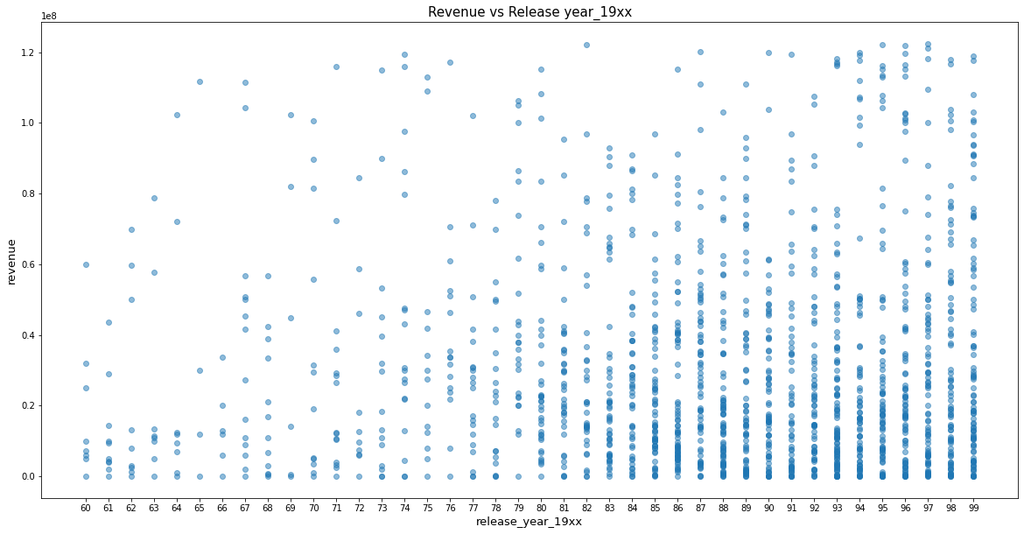

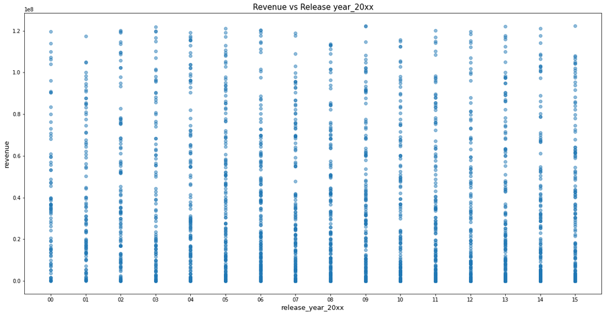

```python
default_color = sb.color_palette()[0]

plt.figure(figsize=(20,10))

plt.scatter(data = year_revenue_19xx, x='release_year',y = 'revenue',alpha=1/2)
plt.xlabel('release_year_19xx',fontsize=13)
plt.ylabel('revenue',fontsize=13)
plt.title('Revenue vs Release year_19xx',fontsize=15);

plt.figure(figsize=(20,10))
plt.scatter(data = year_revenue_20xx, x='release_year',y = 'revenue',alpha=1/2)
plt.xlabel('release_year_20xx',fontsize=13)
plt.ylabel('revenue',fontsize=13)
plt.title('Revenue vs Release year_20xx',fontsize=15);
```

- Revenue seems have slightly relationship with year for the year before 20xx. With higher year, the renveue gently higher
- Random for renvenue vs release year in 20xx

### Research Question 2 (Revenue Analysis)

- Dependent variable: revenue, independent variable: all others
- Question: What kinds of properties are associated with movies that have high revenues?

```python
from sklearn.preprocessing import StandardScaler

# Get column names first
cols_to_norm = ['popularity','budget','revenue','vote_count','vote_average','revenue_adj']
df[cols_to_norm] = StandardScaler().fit_transform(df[cols_to_norm])
```

- positive relationship, in certain range, higher popularity, higher revenue

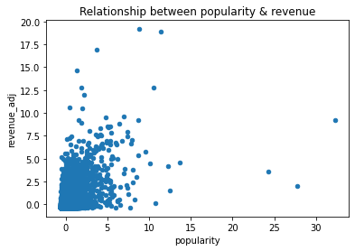

```python
df.plot.scatter(x= 'popularity', y ='revenue_adj', title = 'Relationship between popularity & revenue');
#plt.scatter(x= df.popularity, y = df.revenue_adj);
```

- positive relationship, in most of the cases, higher budget, higher revenue

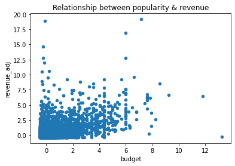

```python
df.plot.scatter(x= 'budget', y ='revenue_adj', title = 'Relationship between popularity & revenue');
```

```python
#df.plot.scatter(x= 'runtime', y ='revenue_adj', title = 'Relationship between popularity & revenue');
count_runtime = df.groupby('runtime').count()['popularity']
count_runtime.head()
```

```
runtime
0    30
2     4
3    10
4    17
5    16
Name: popularity, dtype: int64
```

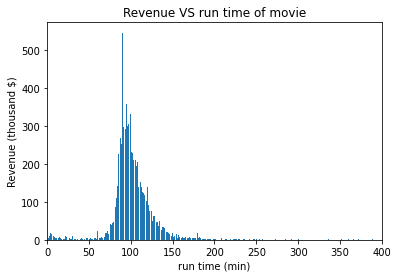

```python
plt.bar(count_runtime.index, count_runtime)
plt.xlim(0, 400)
plt.title("Revenue VS run time of movie")
plt.xlabel("run time (min)")
plt.ylabel("Revenue (thousand $)");
```

```python
#df.plot.bar(x= 'release_year', y ='revenue_adj', title = 'Relationship between popularity & revenue');
count_release = df.groupby('release_year').count()['popularity']
count_release.head()
```

```
release_year
1960    32
1961    31
1962    32
1963    34
1964    42
Name: popularity, dtype: int64
```

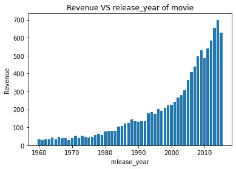

```python
plt.bar(count_release.index, count_release)
plt.title("Revenue VS release_year of movie")
plt.xlabel("release_year")
plt.ylabel("Revenue");
```